```python
from IPython.core.display import HTML
HTML("""
<style>
.output_png {
        display: table-cell;
        text-align: center;
        margin:auto;
    }
.prompt{
    display:none;
}
</style>
""")
```

# Citation Prediction using Altmetrics

Fabio Grassi

October 26<sup>th</sup> 2018

Aalto University, Espoo, Finland

```python
import pandas as pd
import matplotlib.pyplot as plt
import numpy as np
import scipy as sp
import seaborn as sns
import plotly.graph_objs as go
from plotly.offline import download_plotlyjs, init_notebook_mode, plot, iplot
from IPython.display import Image
from sklearn.metrics import r2_score
from sklearn.preprocessing import StandardScaler
from sklearn.model_selection import train_test_split, GridSearchCV, cross_val_score, KFold
from sklearn.linear_model import ARDRegression, BayesianRidge, ElasticNet, Lasso
from sklearn.svm import LinearSVR, SVR
from sklearn.gaussian_process import GaussianProcessRegressor
from sklearn.neighbors import KNeighborsRegressor
from sklearn.neural_network import MLPRegressor
from sklearn.pipeline import Pipeline
```

```python
df = pd.read_csv("data.csv")
```

## The data set

The data set provided included seventeen columns, eleven of which were Altmetrics.

```python
startingcolumns = [i.capitalize() for i in df.columns]

coldescription = ["Number of Authors", "Number of Fields", "Article Title",
                  "Year of Publication", "Open Access", "Number of Citations"] + ["Altmetric Name" for i in range(11)]

descr = pd.DataFrame(list(zip(startingcolumns, coldescription)),
                     columns=["Name","Description"],
                     index=["" for i in range(len(df.columns))])

descr
```

|  | Name | Description |
| --- | --- | --- |
|  | Authors | Number of Authors |
|  | Fields | Number of Fields |
|  | Title | Article Title |
|  | Year | Year of Publication |
|  | Oa | Open Access |
|  | Citations | Number of Citations |
|  | Mendeley | Altmetric Name |
|  | Gplus | Altmetric Name |
|  | Facebook | Altmetric Name |
|  | Twitter | Altmetric Name |
|  | Feeds | Altmetric Name |
|  | Reddit | Altmetric Name |
|  | News | Altmetric Name |
|  | Policy | Altmetric Name |
|  | Wikipedia | Altmetric Name |
|  | Youtube | Altmetric Name |
|  | Weibo | Altmetric Name |

### Year

The articles in the data set were published in the period between 2015 and 2017.

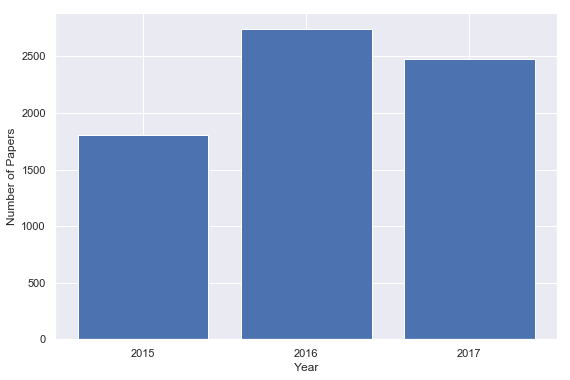

```python
plt.figure(figsize=(9,6))
plt.bar([2015,2016,2017],
         [len(df.loc[df.year==2015]), len(df.loc[df.year==2016]), len(df.loc[df.year==2017])])
plt.xticks([2015,2016,2017])
plt.ylabel("Number of Papers")
plt.xlabel("Year")
plt.show()

# Note: changing year to 1, 2, and 3.

df["year"] = [1 if i == 2017 else 2 if i == 2016 else 3 for i in df.year]
```

### Open Access

Open Access refers to publications which are available without restrictions such as subscription fees.Currently there is no consensus on the impact of open access status on citation count: several studies report a positive correlation between the two, particularly for "gold" open access, while others question these findings and suggest that no relationship is present.

[figure not shown]

```python
Image("./openaccess.png")
```

Approximately 37 % of the articles in the data set were marked as Open Access.

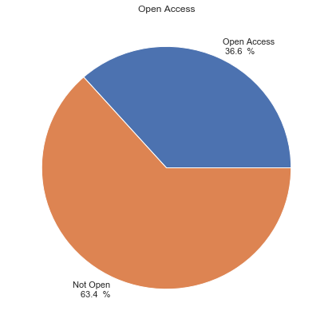

```python
plt.figure(figsize=(7,7))
yes = len(df.loc[df.oa == 1])
no = len(df.loc[df.oa == 0])
percentyes = round(yes/(yes+no)*100,1)
percentno = 100-percentyes
plt.pie([len(df.loc[df.oa == 1]), len(df.loc[df.oa == 0])],
        labels=["Open Access\n %s " % percentyes + " %",
                "Not Open\n %s " % percentno + " %"])
plt.title("Open Access")
plt.show()
```

Our data indicates a noticeably different behavior for open and restricted access articles: open access articles have a significantly higher citation count on average (6.0 vs 2.9).

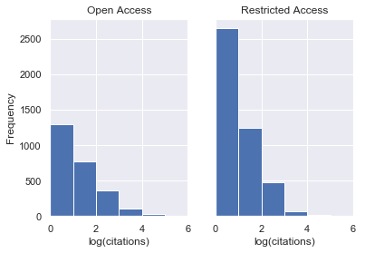

```python
ybar = [df.loc[df.oa == 0].citations.mean(),df.loc[df.oa == 1].citations.mean()]
yerr = [df.loc[df.oa == 0].citations.std(),df.loc[df.oa == 1].citations.std()]

f,(ax0,ax1) = plt.subplots(1,2,sharey=True)
ax0.set_xlim(0,6)
ax0.set_xlabel("log(citations)")
ax0.set_ylabel("Frequency")
ax0.set_title("Open Access")
ax0.hist(np.log(df.loc[df.oa == 1].citations+1),bins=np.arange(6))
ax1.set_xlim(0,6)
ax1.set_xlabel("log(citations)")
ax1.set_title("Restricted Access")
ax1.hist(np.log(df.loc[df.oa == 0].citations+1),bins=np.arange(6))
plt.show()
```

```python
# sp.stats.mannwhitneyu(df.loc[df.oa == 0].citations, df.loc[df.oa == 1].citations, alternative="two-sided")
```

### Fields

Every paper had associated to it a value to describe the number of academic fields it covered, and it serves as a measure of multidisciplinarity.

```python
df["fields"] = [i if i > 0 else df.fields.median() for i in df.fields]

byfield = pd.DataFrame(list(zip(np.arange(1,int(max(df.fields))+1),
                                [round(df.loc[df.fields == i].citations.mean(),1) for i in range(1,int(max(df.fields)+1))],
                                [round(df.loc[df.fields == i].citations.std(),1) for i in range(1,int(max(df.fields)+1))])),
                       columns=["Fields","Mean","Std. Dev."],
                       index = ["" for i in range(6)])
```

```python
# Note: 13 articles had a fields value of 0. As this should not be possible, these are considered to be mislabelled,
# and their value will be reset to the median value.

df["fields"] = [i if i > 0 else df.fields.median() for i in df.fields]
```

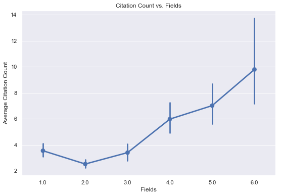

```python
plt.figure(figsize=(9,6))
sns.set(style="darkgrid")
sns.pointplot(x="fields",y="citations",data=df,ci=95)
plt.xlabel("Fields")
plt.ylabel("Average Citation Count")
plt.title("Citation Count vs. Fields")
plt.show()
```

```python
#sp.stats.kruskal(*[df.loc[df.fields == i].citations for i in range(1,7)])
```

Multidisciplinarity appears to correlate with citation count, and the difference between the means is statistically significant.

```python
# Legacy code. Ignore.

#words = []
#for i in df.title:
#    words += i.split()

#words = list(set(words))
```

```python
# Legacy code. Ignore.

#wcit = []
#tmp = list(df.title)
#for w in words:
#    cit = 0
#    for i in range(len(df)):
#        if w in tmp[i].split():
#            cit += df.citations[i]
#    wcit.append(cit)

#wordcit = pd.DataFrame(list(zip(words,wcit)),columns=["words","cit"])
#wordcit["len"] = [len(i) for i in wordcit.words]
```

### Title

[figure not shown]

```python
Image("./titlelength.png")
```

Included in the data set were the titles of the articles, stripped of punctuation. The literature available on the relationship between article title and citations suggests that shorter titles correlate with higher citation counts. A new feature, *title length*, was therefore extracted from the title.

```python
df["lentitle"] = [len(i.split()) for i in df.title]
```

```python
sp.stats.spearmanr(df.lentitle, df.citations)
```

```
SpearmanrResult(correlation=0.08234290615931225, pvalue=4.8083971096589835e-12)
```

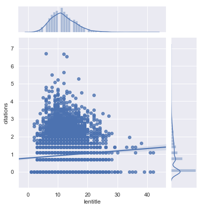

```python
g = sns.JointGrid(df.lentitle,np.log(df.citations+1))
g.plot(sns.regplot,sns.distplot)
```

### Altmetric Availability

Of all the articles in the data set, **less than 30 %** had at least one altmetric associated to them, while for the rest no altmetrics data was available.

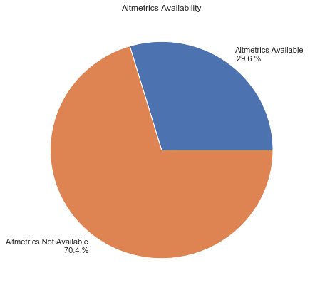

```python
plt.figure(figsize=(7,7))
yes = len(df.mendeley.dropna())
no = len(df) - len(df.mendeley.dropna())
percentyes = round(yes/(yes+no)*100,1)
percentno = 100-percentyes
plt.pie([yes, no],
        labels=["Altmetrics Available\n %s " % percentyes + "%",
                "Altmetrics Not Available\n %s " % percentno + "%"])
plt.title("Altmetrics Availability")
plt.show()
```

With such a high fraction of unavailable data, standard techniques for handling missing data cannot be applied. Furthermore, the distribution of the missing data does not appear to be random: the two groups appear to be noticeably different, as can be observed in the two histograms below.

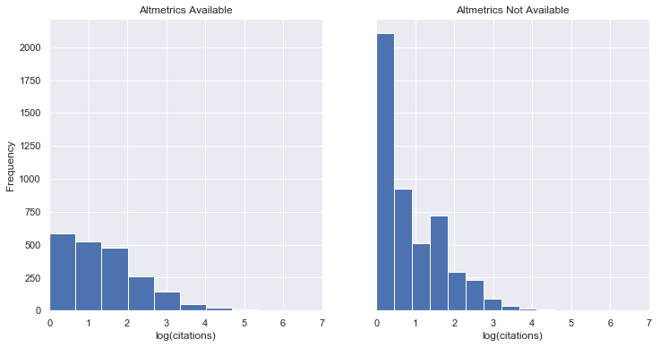

```python
f, (ax1, ax2) = plt.subplots(1,2,sharey=True)
f.set_figheight(6)
f.set_figwidth(12)
yes = np.log(df.loc[df.mendeley.isnull() == False].citations+1)
no = np.log(df.loc[df.mendeley.isnull() == True].citations+1)
ax1.hist(yes)#,bins=np.arange(yes.max()))
ax1.set_title("Altmetrics Available")
ax1.set_xlabel("log(citations)")
ax1.set_ylabel("Frequency")
ax1.set_xlim(0,7)
ax2.hist(no)#,bins=np.arange(no.max()))
ax2.set_title("Altmetrics Not Available")
ax2.set_xlabel("log(citations)")
#ax2.set_ylabel("Frequency")
ax2.set_xlim(0,7)
plt.show()
```

Statistical testing performed on the citations for articles with missing vs. non-missing altmetrics strongly suggests that these are two distinct populations.

```python
#
# Run this cell to verify the statement above. p value is < 10**(-50).
#
#sp.stats.mannwhitneyu(df.loc[df.mendeley.isnull() == False].citations,
#                      df.loc[df.mendeley.isnull() == True].citations,
#                      alternative="two-sided")
```

### Altmetric Distribution

The most common altmetric is Mendeley, with 2080 non-null values, followed by Twitter with 1942. All other altmetrics had less than 500 mentions.

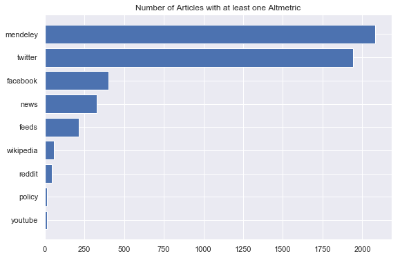

```python
altmetrics = ["mendeley","facebook","twitter","feeds","reddit","news","policy","wikipedia","youtube"]

plt.figure(figsize=(9,6))

altlengths = pd.DataFrame(list(zip([len(df.loc[df[i].isnull() == False]) for i in altmetrics],altmetrics)),
                          columns = ["available","altmetrics"])

sortedalt = altlengths.sort_values(by="available",ascending=True)

plt.barh(range(len(altmetrics)),
         sortedalt.available)
plt.yticks(range(len(altmetrics)),
           sortedalt.altmetrics)

plt.title("Number of Articles with at least one Altmetric")

plt.show()
```

Some articles had mentions on multiple altmetrics, and all articles with altmetrics had a Mendeley value. Weibo was dropped as it is no longer being tracked by Altmetric.com. GPlus was also dropped, as Google announced in October 2018 that it will discontinue the service in 2019.

```python
df = df.drop(["gplus","weibo"],axis=1)
```

### Altmetrics vs Citations

Visualization of altmetric mentions vs. citation count indicates that there may be a correlation for **Mendeley**. Other altmetrics appear to be less correlated.

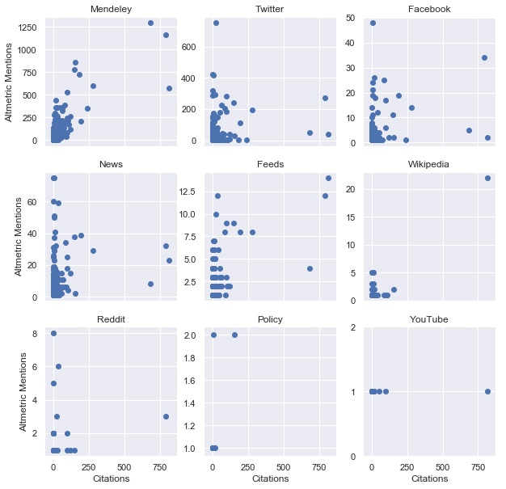

```python
f,((ax0,ax1,ax2),(ax3,ax4,ax5),(ax6,ax7,ax8)) = plt.subplots(3,3,sharex=True)

alt = lambda x: df.loc[df[x].isnull() == False]

f.set_figheight(10)
f.set_figwidth(10)
ax0.scatter(alt("mendeley").citations, alt("mendeley").mendeley)
ax0.set_title("Mendeley")
ax0.set_ylabel("Altmetric Mentions")
ax1.scatter(alt("twitter").citations, alt("twitter").twitter)
ax1.set_title("Twitter")
ax2.scatter(alt("facebook").citations, alt("facebook").facebook)
ax2.set_title("Facebook")
ax3.scatter(alt("news").citations, alt("news").news)
ax3.set_title("News")
ax3.set_ylabel("Altmetric Mentions")
ax4.scatter(alt("feeds").citations, alt("feeds").feeds)
ax4.set_title("Feeds")
ax5.scatter(alt("wikipedia").citations, alt("wikipedia").wikipedia)
ax5.set_title("Wikipedia")
ax6.scatter(alt("reddit").citations, alt("reddit").reddit)
ax6.set_title("Reddit")
ax6.set_xlabel("Citations")
ax6.set_ylabel("Altmetric Mentions")
ax7.scatter(alt("policy").citations, alt("policy").policy)
ax7.set_xlabel("Citations")
ax7.set_title("Policy")
ax8.scatter(alt("youtube").citations, alt("youtube").youtube)
ax8.set_ylim(0,2)
ax8.set_yticks([0,1,2])
ax8.set_xlabel("Citations")
ax8.set_title("YouTube")
plt.show()
```

This was confirmed by calculating the Spearman correlation coefficnents for altmetrics and citation count. **Mendeley mentions appear to be strongly correlated with citations**. Other altmetrics are confirmed to be weakly correlated.

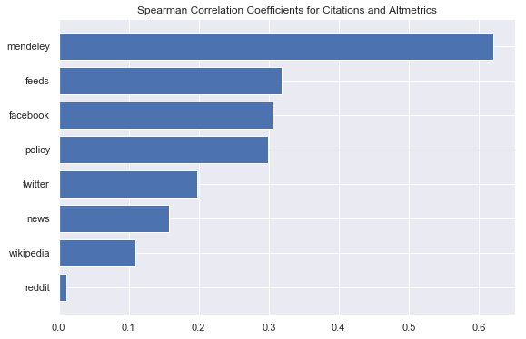

```python
# Using Spearman rather than Pearson as it is more robust to outliers.

altcorr = pd.DataFrame(list(zip([df[["citations",i]].corr(method="spearman")[i][0] for i in altmetrics],
                                altmetrics)),
                       columns = ["spearman","altmetrics"]).sort_values(by="spearman")

plt.figure(figsize=(9,6))

plt.barh(range(len(altmetrics)-1),
         altcorr.spearman[:-1])

plt.yticks(range(len(altmetrics)-1),
           altcorr.altmetrics[:-1])

plt.title("Spearman Correlation Coefficients for Citations and Altmetrics")

plt.show()

#plt.barh([df[["citations",i]].loc[df[i].isnull() == False].corr()[i][1]])
```

Based on these observations, and considering that to include other altmetrics would require reducing the size of the data set even further, it was decided to **keep Mendeley as the only altmetric to be used in the model**. Missing values were set to zero and, to preserve the information on the missing article a new binary feature was introduced to mark articles which were missing Mendeley data.

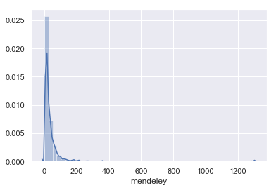

```python
sns.distplot(df.loc[df.mendeley.isnull() == False].mendeley)
plt.show()
```

## Model Selection and Evaluation

Six different algorithms were tried:

- Random Forests
- K-Nearest Neighbors
- Neural Network
- Support Vector Machines (Linear, RBF, Polynomial)

```python
df["missing"] = [1 if i == True else 0 for i in df.mendeley.isnull()]
imputed = df.fillna(0)
imputed["authors"] = np.log(imputed.authors)
imputed["mendeley"] = np.cbrt(imputed.mendeley)
```

```python
mms = MinMaxScaler()
ss = StandardScaler()

lr = LinearSVR()
knn = KNeighborsRegressor(weights="distance", n_neighbors=5)
rf = RandomForestRegressor(n_estimators=50)
svr = SVR(kernel="poly")
svrrbf = SVR(kernel="rbf")
nn = MLPRegressor(hidden_layer_sizes=(72,36),activation="relu",learning_rate="adaptive",max_iter=1000)

def score(transformer, estimator):
    pipe = Pipeline([('transformer', transformer), ('estimator', estimator)])
    cv = KFold(n_splits=10)
    return(cross_val_score(pipe,
                           imputed[["authors","fields","year","oa","mendeley","missing"]],
                           imputed["citations"],
                           cv=cv))
```

```python
scknn = score(ss, knn)
scrf = cross_val_score(RandomForestRegressor(n_estimators=50),
                       imputed[["authors","fields","year","oa","mendeley","missing"]],
                       imputed["citations"],
                       cv = KFold(n_splits=10))
sclr = score(ss, LinearSVR())
scsvr = score(ss, svr)
scnn = score(mms, nn)
svrrbf = SVR(kernel="rbf")
```

Scoring of Machine Learning Algorithms

```python
init_notebook_mode(connected=True)
KNN = go.Box(y=scknn, name="K-Neareast Neighbors")
RandomForest = go.Box(y=scrf, name="Random Forest")
LR = go.Box(y=sclr,name="SVR (Linear)")
SVM = go.Box(y=scsvr,name="SVR (Polynomial)")
SVMRBF = go.Box(y=scsvrrbf,name="SVR (RBF)")
NeuralNetwork = go.Box(y=scnn, name="Neural Network")
iplot([LR,SVMRBF,RandomForest,KNN,NeuralNetwork,SVM])
```

[interactive chart not shown]

The best performing algorithm was SVM with polynomial kernel, with a median R<sup>2</sup> score of 0.39.

During testing, it was observed that the information on title length decreased the performance of the algorithms, and it was therefore dropped. By analysing the training and test sets used to calculate the scores, it was found that higher scores were recorded when the mean citation count was similar in both training and test sets, and vice versa: this is a sign that the model is struggling to generalize the problem, likely due to insufficient data.

After hyperparameter optimization, the median R<sup>2</sup> was further increased to 0.43. As a final test, the model was then used to predict the total number of citations for papers published in 2015, based on the data from 2016 and 2017.

```python
sv = SVR(kernel="poly",cache_size=2000)
grid = {
    "degree":[2,3,4],
    "C":[1,0.1,0.01],
    "epsilon":[1,0.1]
}
gs = GridSearchCV(sv,grid,scoring="r2",verbose=False)
gs.fit(sstr, cit1)
x=1
```

```python
finaltrain = imputed.loc[imputed.year < 3]
finaltest = imputed.loc[imputed.year == 3]
finalmodel = SVR(kernel="poly",cache_size=2000,degree=3,C=0.1,epsilon=0.1)

finalmodel.fit(finaltrain[["authors","fields","year","oa","mendeley","missing"]],
               finaltrain["citations"])

#r2_score(finaltest["citations"],finalmodel.predict(finaltest[["authors","fields","year","oa","mendeley","missing"]]))
x=1
```

```python
y2015predict = finalmodel.predict(finaltest[["authors","fields","year","oa","mendeley","missing"]]).sum()
y2015actual = finaltest["citations"].sum()
```

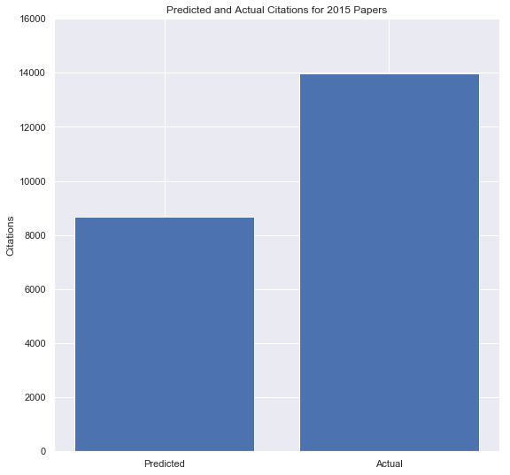

```python
plt.figure(figsize=(9,9))
plt.title("Predicted and Actual Citations for 2015 Papers")
plt.bar([0,1],[y2015predict,y2015actual])
plt.ylim(0,16000)
plt.xticks([0,1],["Predicted","Actual"])
plt.ylabel("Citations")
plt.show()
```

The model predicted a total of 8686 citations, underestimating the total citation count by 37 %.

# Final Comments

A machine learning model can only be as good as the data that it learns from. The model described is a good starting point, but by improving the quality of the data, we can aim for much more reliable predictions. This can be done in several ways:

- Including author information: it is a well known fact that some authors attract more citations than others for a number of reasons (skill, reputation, networking...). Adding the main author's H-Index would likely help to train a better model.
- Including impact factor: an article published on Nature will likely attract more attention than one published on a low-impact factor journal.
- Including field information: some fields of research generate more citations than others.
- Collecting data at regular time intervals. The data set used in this investigation provided a snapshot of the citation counts and altmetrics at a given point in time. By following the time evolution of these metrics, we can provide valuable information to the algorithm, e.g. knowing how many citations a certain article had after six months, one year, two years...
- Understanding why so many data points are missing for altmetrics.